# performance

## Feature selection using caret

```r
control <- rfeControl(functions = rfFuncs,method = "repeatedcv",repeats = 3,verbose = FALSE)

predictors<-names(trainset)[!names(trainset) %in% outcomeName]
Loan_Pred_Profile <- rfe(trainset[,predictors], trainset[,outcomeName],rfeControl = control)
```

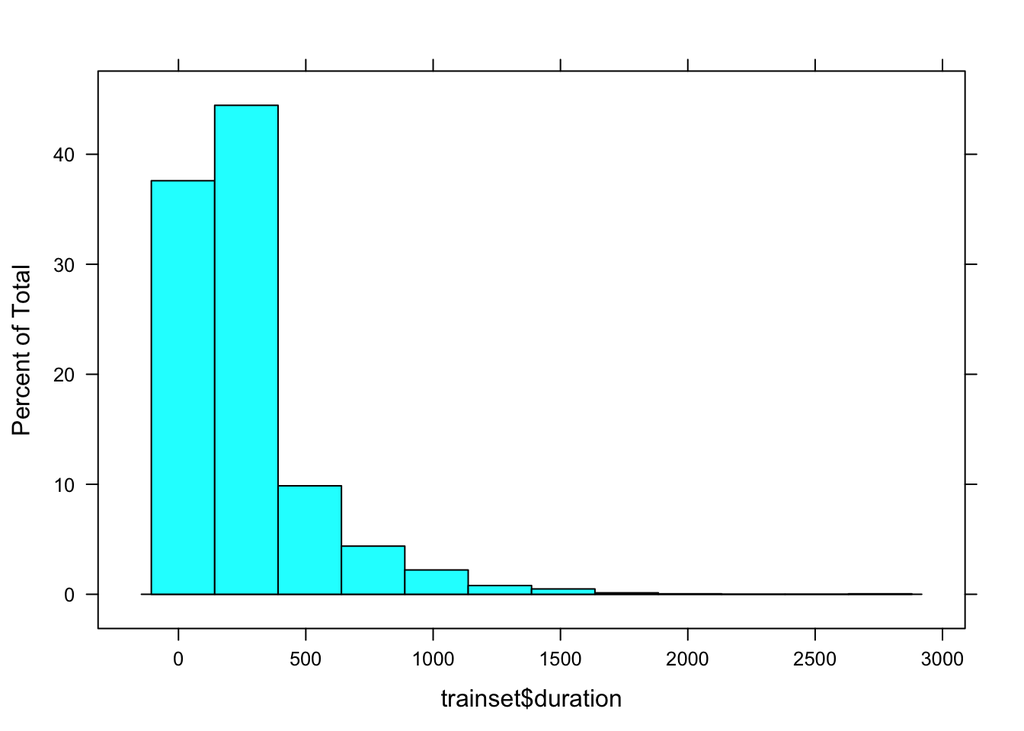

```r
predictors<-c("duration", "month", "poutcome", "pdays", "previous")

histogram(trainset$duration)
```

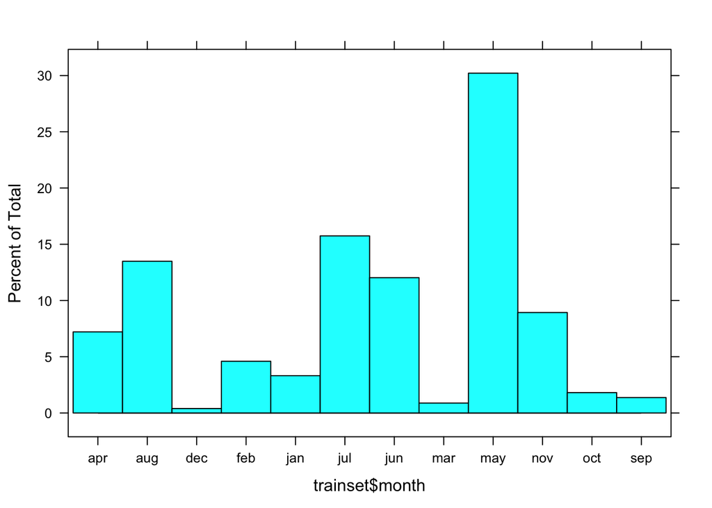

```r
histogram(trainset$month)
```

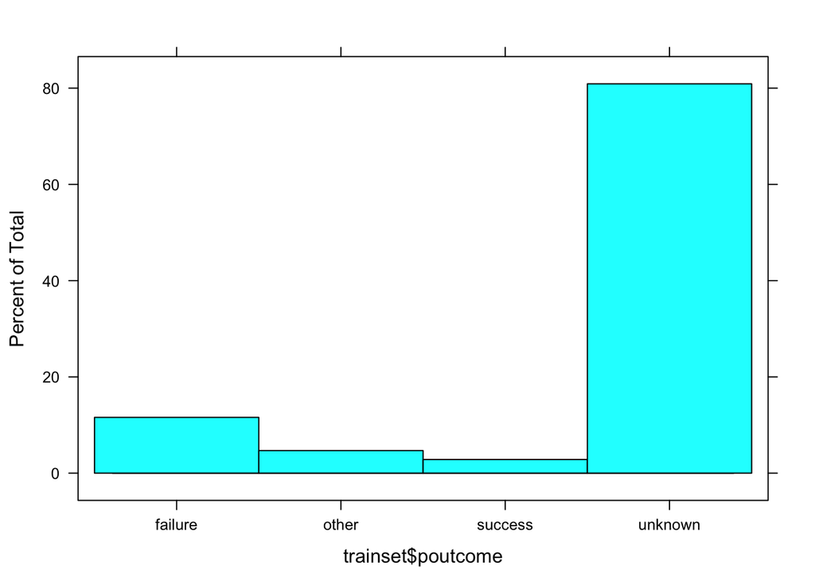

```r
histogram(trainset$poutcome)
```

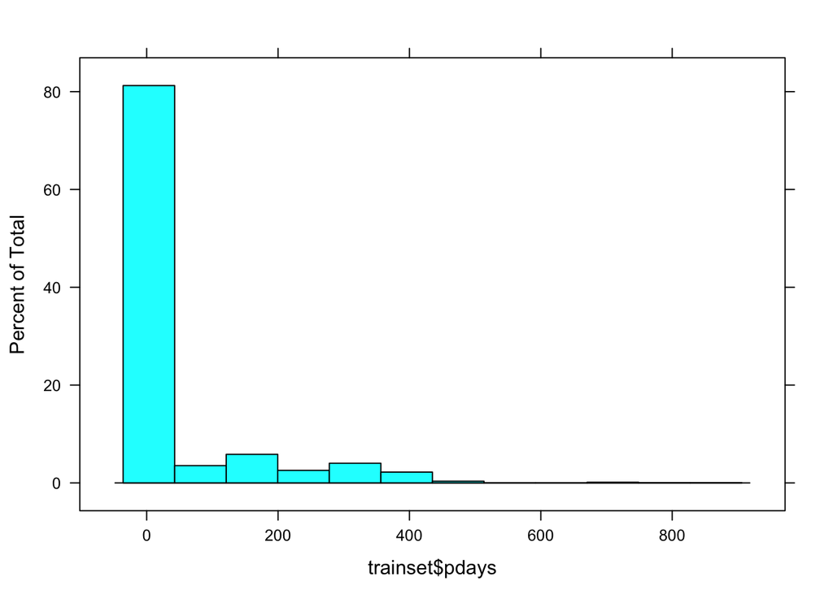

```r
histogram(trainset$pdays)
```

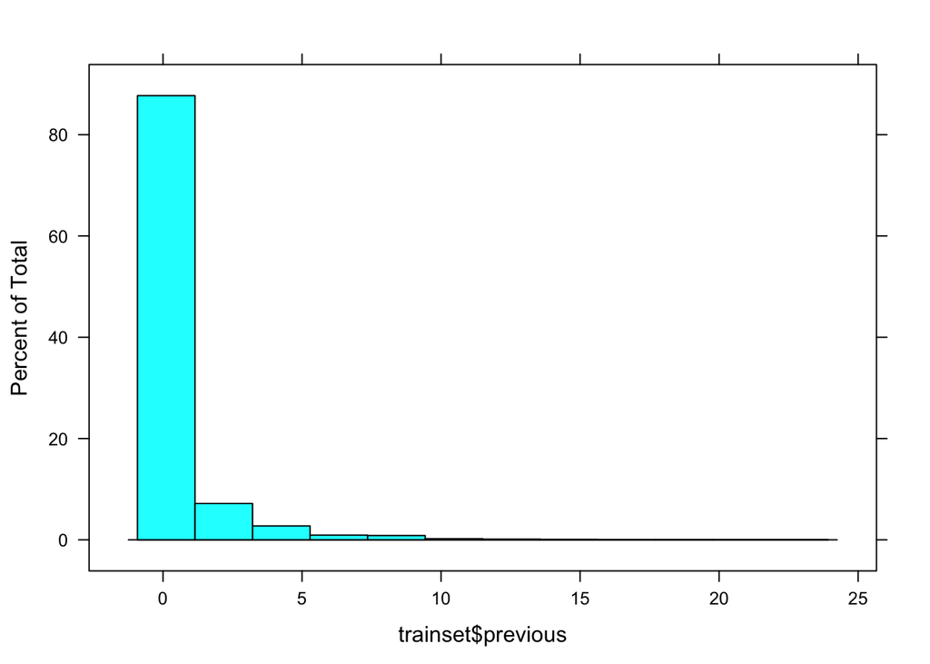

```r
histogram(trainset$previous)
```

## Training the model

Apply GBM, Random forest, Neural Net and Logistic Regression

```r
model_gbm<-train(trainset[,predictors],trainset[,outcomeName],method='gbm')
model_rf<-train(trainset[,predictors],trainset[,outcomeName],method='rf')
model_nnet<-train(trainset[,predictors],trainset[,outcomeName],method='nnet')
model_glm<-train(trainset[,predictors],trainset[,outcomeName],method='glm')
```

## Prediction

Predict the outcome of test data and then evaluate the model performance

## Evaluate the random forest model using the metrics

```r
predict<-predict.train(object=model_rf,testset[,predictors],type="raw")
table(predict)
confusionMatrix(predict,testset[,outcomeName])
```

## Model performance for Random Forest

confusion matric for the Random Forest model

| Prediction | no | yes |
| --- | --- | --- |
| No | 1927 | 161 |
| Yes | 73 | 99 |

## evaluate the GBM model and find the metrics

```r
predict<-predict.train(object=model_gbm,testset[,predictors],type="raw")
table(predict)
confusionMatrix(predict,testset[,outcomeName])
```

## Model performance for GBM

confusion matric for the GBM model

| Prediction | no | yes |
| --- | --- | --- |
| No | 1954 | 189 |
| Yes | 46 | 71 |

## evaluate the Neural Net model and calculate the metrics.

```r
predict<-predict.train(object=model_nnet,testset[,predictors],type="raw")
table(predict)
confusionMatrix(predict,testset[,outcomeName])
```

## Model performance for Neural Networks

confusion matric for the Neural Networks

| Prediction | no | yes |
| --- | --- | --- |
| No | 1930 | 147 |
| Yes | 70 | 113 |

## evaluate the glm and calculate the metrics.

```r
predict<-predict.train(object=model_glm,testset[,predictors],type="raw")
confusionMatrix(predict,testset[,outcomeName])
```

## Model performance for Logistic Regression

confusion matric for the Logistic Regression

| Prediction | no | yes |
| --- | --- | --- |
| No | 1962 | 179 |
| Yes | 38 | 81 |

## Conclusion

Calculated the performance metrics, accuracy, Sensitivity,Specificity, and Kappa. As per these metrics, We can either Random Forest or Neural Network model can be used for this classification problem.

[output not shown]